# Design Vignette: dsuds

Laura Marshall

2019-06-10

## Introduction

‘dsuds’ is a package for designing distance sampling surveys in R. It currently offers a number of design options: systematic points, systematic lines, randomly lines, equal spaced zigzagz and equal spaces zigzags with complement lines. Different types of line transect designs may be used in different strata.

## Defining the Study Area

Users can define a study area by either passing in a pathway to a shapefile or providing a polygon / multipolygon shape of class sf or sfc (see ‘sf’ R library). Other options will be added in the future including the option to provide sp objects, data frames or lists of data frames.

The user can provide a region name and names for strata if applicable. If no strata names are provided and the study area has multiple strata these will be automatically assigned as letters of the alpabet.

```r
library(dsuds)
region <- make.region(region.name = "study.area", shape = "/Users/lhm/Documents/GitHub/dsuds/dsuds/inst/extdata/shape/strata.shp")
```

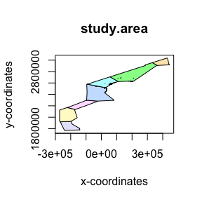

```r
plot(region)
```

If no shape is supplied for the region The design package will make a default study area with the same dimensions as that in the simulation package ‘DSsim’ 2000 x 500.

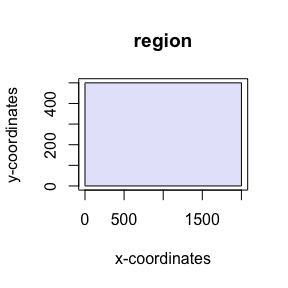

```r
default.region <- make.region()
plot(default.region)
```

## Defining the Design

‘dsuds’ can generate two types of transect designs: points and lines. The default design is 20 systematic parallel lines with a design angle of 0, meaning that the lines run perpendicular to the x axis.

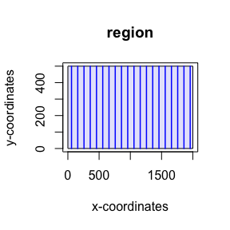

```r
default.design <- make.design(default.region)
transects <- generate.transects(default.design)
plot(default.region, transects, lwd = 1.5, col = 4)
```

## Point transect surveys

I have implemented the systematic point transect design. This design can have different design arguments such as spacing, design.angle, no.samplers and plus/minus sampling for each strata. I have yet to implement the summary methods for the point transect objects so I have included details about what I will show.

```r
region <- make.region("study area", c("A", "B"), shape = "/Users/lhm/Documents/Work/design package/sf investigations/strata.shp")
design <- make.design(region, transect.type = "point",
                      design = "systematic",
                      spacing = c(1,2),
                      edge.protocol = c("plus", "minus"),
                      design.angle = c(0,45),
                      truncation = 1)
transects <- generate.transects(design)
transects
```

```
##
##    Strata A:
##    __________
## Design:  systematically spaced transects
## Spacing:  1
## Number of samplers:  144
## Design angle:  0
## Edge protocol:  plus
## Covered area:  310.8756
## Strata coverage:  314.02 %
##
##    Strata B:
##    __________
## Design:  systematically spaced transects
## Spacing:  2
## Number of samplers:  28
## Design angle:  45
## Edge protocol:  minus
## Covered area:  74.09599
## Strata coverage:  74.1 %
##
##    Study Area Totals:
##    _________________
## Number of samplers:  172
## Covered area:  384.9716
## Average coverage:  193.45 %
```

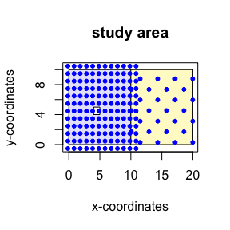

```r
plot(region, transects)
```

The next example uses the desired number of samplers to determine the spacing. In this example the spacing is based on a calculation involving the strata area however in the case of plus sampling should this calculation be based on the buffered survey region? Otherwise it will generate many more than the desired number of points.

```r
design <- make.design(region, "point", "systematic",
                      samplers = c(20,20),
                      edge.protocol = c("minus"),
                      design.angle = c(0,45),
                      truncation = 1)
transects <- generate.transects(design)
transects
```

```
##
##    Strata A:
##    __________
## Design:  systematically spaced transects
## Spacing:  2.22486
## Number of samplers:  19
## Design angle:  0
## Edge protocol:  minus
## Covered area:  53.66722
## Strata coverage:  54.21 %
##
##    Strata B:
##    __________
## Design:  systematically spaced transects
## Spacing:  2.236068
## Number of samplers:  18
## Design angle:  45
## Edge protocol:  minus
## Covered area:  56.28061
## Strata coverage:  56.28 %
##
##    Study Area Totals:
##    _________________
## Number of samplers:  37
## Covered area:  109.9478
## Average coverage:  55.25 %
```

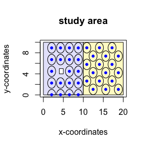

```r
plot(region, transects, covered.area = TRUE)
```

This next example demonstrates when the user would like even coverage and would like to define the desired number of samplers across the entire study region rather than by strata.

```r
design <- make.design(region, "point", "systematic",
                      samplers = c(40),
                      edge.protocol = c("minus"),
                      design.angle = c(0,45),
                      truncation = 1)
transects <- generate.transects(design)
transects
```

```
##
##    Strata A:
##    __________
## Design:  systematically spaced transects
## Spacing:  2.230471
## Number of samplers:  20
## Design angle:  0
## Edge protocol:  minus
## Covered area:  57.43377
## Strata coverage:  58.01 %
##
##    Strata B:
##    __________
## Design:  systematically spaced transects
## Spacing:  2.230471
## Number of samplers:  24
## Design angle:  45
## Edge protocol:  minus
## Covered area:  62.87805
## Strata coverage:  62.88 %
##
##    Study Area Totals:
##    _________________
## Number of samplers:  44
## Covered area:  120.3118
## Average coverage:  60.46 %
```

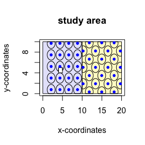

```r
plot(region, transects, covered.area = TRUE)
```

```r
design <- make.design(region, "point", "systematic",
                      samplers = c(20, NA),
                      spacing = c(NA, 2),
                      edge.protocol = c("minus"),
                      design.angle = c(45),
                      truncation = 0.75)
transects <- generate.transects(design)
transects
```

```
##
##    Strata A:
##    __________
## Design:  systematically spaced transects
## Spacing:  2.22486
## Number of samplers:  21
## Design angle:  45
## Edge protocol:  minus
## Covered area:  34.10265
## Strata coverage:  34.45 %
##
##    Strata B:
##    __________
## Design:  systematically spaced transects
## Spacing:  2
## Number of samplers:  25
## Design angle:  45
## Edge protocol:  minus
## Covered area:  41.29751
## Strata coverage:  41.3 %
##
##    Study Area Totals:
##    _________________
## Number of samplers:  46
## Covered area:  75.40016
## Average coverage:  37.89 %
```

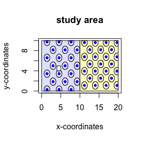

```r
plot(region, transects, covered.area = TRUE)
```

```r
design <- make.design(region, "point", "systematic",
                      samplers = c(40),
                      effort.allocation = c(0.25,0.75),
                      edge.protocol = c("minus"),
                      design.angle = 45,
                      truncation = 1)
transects <- generate.transects(design)
transects
```

```
##
##    Strata A:
##    __________
## Design:  systematically spaced transects
## Spacing:  3.146427
## Number of samplers:  12
## Design angle:  45
## Edge protocol:  minus
## Covered area:  33.38517
## Strata coverage:  33.72 %
##
##    Strata B:
##    __________
## Design:  systematically spaced transects
## Spacing:  1.825742
## Number of samplers:  28
## Design angle:  45
## Edge protocol:  minus
## Covered area:  83.21857
## Strata coverage:  83.22 %
##
##    Study Area Totals:
##    _________________
## Number of samplers:  40
## Effort allocation:  25%, 75 %
## Covered area:  116.6037
## Average coverage:  58.59 %
```

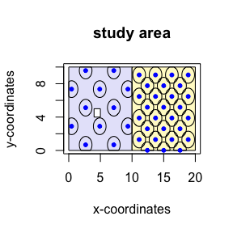

```r
plot(region, transects, covered.area = TRUE)
```

Let us now assess the coverage of a design. It is reccommended that you make a coverage grid and pass it to the make.design function. Doing it this way can be more memory efficient if you are trying multiple designs in the same study region. If you have not passed in a coverage grid when you make the design then when you try to run the coverage you will get a warning and a default grid with 1000 points will be generated. This example demonstrated the difference in coverage around the stratum boundaries with plus and minus sampling.

```r
region <- make.region("study area", c("A", "B"), shape = "/Users/lhm/Documents/Work/design package/sf investigations/strata.shp")
cover <- make.coverage(region, n.grid.point = 500)
design <- make.design(region, transect.type = "point",
                      design = "systematic",
                      spacing = c(2,2),
                      edge.protocol = c("plus", "minus"),
                      design.angle = c(0,0),
                      truncation = 1,
                      coverage.grid = cover)
design <- run.coverage(design, reps = 50)
```

```r
design
```

```
##
##    Strata A:
##    __________
## Design:  systematically spaced transects
## Spacing:  2
## Number of samplers:  NA
## Design angle:  0
## Edge protocol:  plus
##
##    Strata B:
##    __________
## Design:  systematically spaced transects
## Spacing:  2
## Number of samplers:  NA
## Design angle:  0
## Edge protocol:  minus
##
##     Number of samplers:
##
##            A  B Total
## Minimum 35.0 25  60.0
## Mean    35.7 25  60.7
## Median  36.0 25  61.0
## Maximum 36.0 25  61.0
##
##     Covered area:
##
##             A     B  Total
## Minimum 77.50 65.16 142.87
## Mean    77.71 71.81 149.52
## Median  77.65 71.56 149.13
## Maximum 78.09 78.26 156.05
##
##     % of region covered:
##
##            A    B Total
## Minimum 0.78 0.65  0.72
## Mean    0.78 0.72  0.75
## Median  0.78 0.72  0.75
## Maximum 0.79 0.78  0.78
```

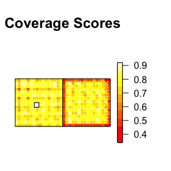

```r
plot(design)
```

## Line transect surveys

This next section deals with line transect surveys. Currently the design package implements 4 types of line transect design: random parallel lines, systematic parallel lines, equal spaced zigzag and equal spaced zigzag with complement lines. Here we use a study region from the SCANS II survey to demonstrate how different designs can be used in different strata.

```r
region <- make.region("region", shape = "/Users/lhm/Documents/GitHub/dsuds/dsuds/inst/extdata/shape/strata.shp")
```

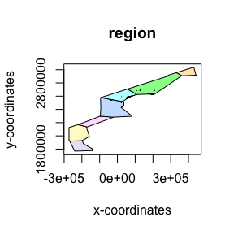

```r
plot(region)
```

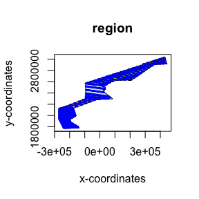

```r
cover <- make.coverage(region, n.grid.points = 1000)
design.mix <- make.design(region,
                          transect.type = "line",
                          design = c(rep("systematic", 2), "eszigzag", "random",
                                     rep("eszigzagcom",2), "systematic"),
                          spacing = c(20000, NA, 20000, NA, 34000, 34000, 20000),
                          samplers = c(NA, 11, NA, 12, NA, NA, NA),
                          design.angle = c(85, 100, 145, 110, 135, 140, 150),
                          bounding.shape = c(NA, NA, "convex.hull", NA,
                                             "convex.hull", "rectangle", NA),
                          edge.protocol = rep("minus", 7),
                          truncation = 7500,
                          coverage.grid = cover)
set.seed(555)
transects.mix <- generate.transects(design.mix)
plot(region, transects.mix, col = 4, covered.area = T)
```

```r
design.mix <- run.coverage(design.mix, reps = 50)
design.mix
```

```
##
##    Strata A:
##    __________
## Design:  systematically spaced transects
## Spacing:  20000
## Number of samplers:  NA
## Design angle:  85
## Edge protocol:  minus
##
##    Strata B:
##    __________
## Design:  systematically spaced transects
## Spacing:  NA
## Number of samplers:  11
## Design angle:  100
## Edge protocol:  minus
##
##    Strata C:
##    __________
## Design:  equal spaced zigzag
## Spacing:  20000
## Number of samplers:  NA
## Design angle:  145
## Edge protocol:  minus
##
##    Strata D:
##    __________
## Design:  randomly located transects
## Number of samplers:  12
## Design angle:  110
## Edge protocol:  minus
##
##    Strata E:
##    __________
## Design:  complementaty equal spaced zigzags
## Spacing:  34000
## Number of samplers:  NA
## Design angle:  135
## Edge protocol:  minus
##
```

[output cut: 42 more lines]

```
## Median  0.74 0.63 0.74 0.67 0.85 0.89 0.72  0.76
## Maximum 0.77 0.64 0.79 0.75 0.88 0.89 0.73  0.78
##
##     Line length:
##
##                A         B        C       D       E       F        G
## Minimum 584812.5  987792.2 612140.4 1262733 1007113 2366051 405793.2
## Mean    645205.4  996841.5 633201.8 1599804 1048270 2433988 423330.7
## Median  671197.5  995869.7 620711.8 1631675 1043848 2447674 422277.6
## Maximum 685121.5 1006765.5 673427.9 1820957 1093273 2463056 435461.2
##           Total
## Minimum 7419608
## Mean    7780641
## Median  7823538
## Maximum 8030503
```

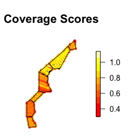

```r
plot(design.mix)
```

### Enhancements/issues yet to do… in order of importance

- Generating line transect surveys by line length (working on it!)
- Generating line transect surveys by total number of samplers
- Sort plotting warning Warning in plot.sf(x@samplers, add = add, col = col, pch = pch): ignoring all but the first attribute
- Dealing with zero effort in some strata
- Cyclic trackline distances for line transect surveys
- Merge/union problematic covered areas rather than removing small ones and hence remove the following warnings: Warning: Removing covered area greater than 100,000th of the strata
- Random point design
- Speed up systematic point design
- Add option to clip covered area polygons to the entire study area rather than the strata polygons (this will give higher coverage where two strata meet)
- Enhanced effort allocation by a sub section of strata only

## Manual creation of study areas

Example of creating a study region manually. This example code is taken from the help file for ‘sf::st_multipolygon’. To create an sf polygon or multipolygon you first need to create 1 or more matrices of coordinates representing the outer polygons and any holes. For multipolygons the outer polygons and holes are defined by their placement within their list element, only the first matrix in a list element is an outer polygon then all the following matrices are holes. In the following example all polygons would be considered to be in the same strata.

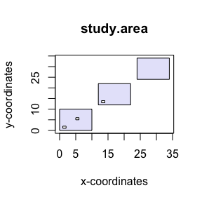

```r
outer <- matrix(c(0,0,10,0,10,10,0,10,0,0),ncol=2, byrow=TRUE)
hole1 <- matrix(c(1,1,1,2,2,2,2,1,1,1),ncol=2, byrow=TRUE)
hole2 <- matrix(c(5,5,5,6,6,6,6,5,5,5),ncol=2, byrow=TRUE)
pol1 <- list(outer, hole1, hole2)
pol2 <- list(outer + 12, hole1 + 12)
pol3 <- list(outer + 24)
mp <- list(pol1,pol2,pol3)
mp1 <- sf::st_multipolygon(mp)

region <- make.region(region.name = "study.area", shape = mp1)
plot(region)
```

If instead you wanted to create the 3 separate polygons as 3 distinct strata you could use the following code:

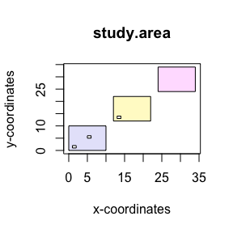

```r
outer <- matrix(c(0,0,10,0,10,10,0,10,0,0),ncol=2, byrow=TRUE)
hole1 <- matrix(c(1,1,1,2,2,2,2,1,1,1),ncol=2, byrow=TRUE)
hole2 <- matrix(c(5,5,5,6,6,6,6,5,5,5),ncol=2, byrow=TRUE)
pol1 <- sf::st_polygon(list(outer, hole1, hole2))
pol2 <- sf::st_polygon(list(outer + 12, hole1 + 12))
pol3 <- sf::st_polygon(list(outer + 24))
sfc <- sf::st_sfc(pol1,pol2,pol3)
strata.names <- c("SW", "central", "NE")
mp1 <- sf::st_sf(strata = strata.names, geom = sfc)

region <- make.region(region.name = "study.area",
                      strata.name = strata.names,
                      shape = mp1)
plot(region)
```